# CP-W05-2-Reflections on Video Quiz Review

- Show All Code
- Hide All Code
- View Source

M05: Reflection on Odds, Log(Odds), Odds Ratio, and Log(OR)

Author

Alexa Bueno

Published

November 12, 2026

# 1 Introduction

This report reflects on the logistic regression fundamentals reviewed in the class recording. The four building blocks of logistic regression are **probability**, **odds**, **log(odds)**, and the **odds ratio (OR)**. I redo the core questions from class step by step, with the answers, the reasoning behind them, and the R code. I want to be able to explain each concept on the exam, not just compute it.

**NoteWhy This Matters**

Linear regression predicts a number that can go anywhere from $-\infty$ to $+\infty$. A probability is stuck between 0 and 1. Logistic regression solves this by modeling the **log(odds)**, which *can* take any value, and then converting the prediction back into a probability.

# 2 From Probability to Odds to Log(Odds)

## 2.1 What Is the Difference Between Probability and Odds?

> **Prompt:** How are probability and odds different, and how do you convert from one to the other?

**Probability** compares the number of times an event happens to the *total* number of chances. **Odds** compare the number of times an event happens to the number of times it *does not* happen.

$$\text{Odds} = \frac{p}{1 - p}
\tag{1}$$

Going the other way, a probability can always be recovered from the odds:

$$p = \frac{\text{Odds}}{1 + \text{Odds}}
\tag{2}$$

For example, if 20 out of 100 customers buy a product:

- Probability of purchase $= 20/100 = 0.20$
- Odds of purchase $= 20/80 = 0.25$, which is read as “1 to 4”

**WarningCommon Mistake**

Odds of 0.25 do **not** mean a 25% chance. Using Equation 2, odds of 0.25 correspond to a probability of $0.25 / 1.25 = 0.20$, or 20%.

## 2.2 Why Do We Take the Log of the Odds?

> **Prompt:** Why does logistic regression use log(odds) instead of probability or odds?

Each transformation stretches the range of the outcome:

Table 1: How each scale changes the range of the outcome

| Scale | Lowest value | Highest value | Value at “50/50” |
| --- | --- | --- | --- |
| Probability | 0 | 1 | 0.5 |
| Odds | 0 | $+\infty$ | 1 |
| Log(odds) | $-\infty$ | $+\infty$ | 0 |

As Table 1 shows, odds remove the upper limit of 1, but they still cannot be negative. Taking the natural log removes the lower limit as well. Log(odds) is also **symmetric** around 0: odds of 3 and odds of 1/3 give log(odds) of $+1.10$ and $-1.10$. This is what lets logistic regression use a straight-line equation, just like linear regression:

$$\log\left(\frac{p}{1-p}\right) = \beta_0 + \beta_1 X
\tag{3}$$

The left side of Equation 3 is called the **logit**.

## 2.3 Converting Between the Three Scales in R

```r
p <- c(0.10, 0.20, 0.25, 0.50, 0.75, 0.90)

scales <- data.frame(
  probability = p,
  odds        = round(p / (1 - p), 3),
  log_odds    = round(log(p / (1 - p)), 3)
)

kable(scales, col.names = c("Probability", "Odds", "Log(odds)"))
```

Table 2: The same event described as a probability, odds, and log(odds)

| Probability | Odds | Log(odds) |
| --- | --- | --- |
| 0.10 | 0.111 | -2.197 |
| 0.20 | 0.250 | -1.386 |
| 0.25 | 0.333 | -1.099 |
| 0.50 | 1.000 | 0.000 |
| 0.75 | 3.000 | 1.099 |
| 0.90 | 9.000 | 2.197 |

Table 2 confirms three rules I should remember:

1. A probability of **0.5** gives odds of **1** and log(odds) of **0**.
2. Probabilities **below 0.5** give odds below 1 and **negative** log(odds).
3. Probabilities **above 0.5** give odds above 1 and **positive** log(odds).

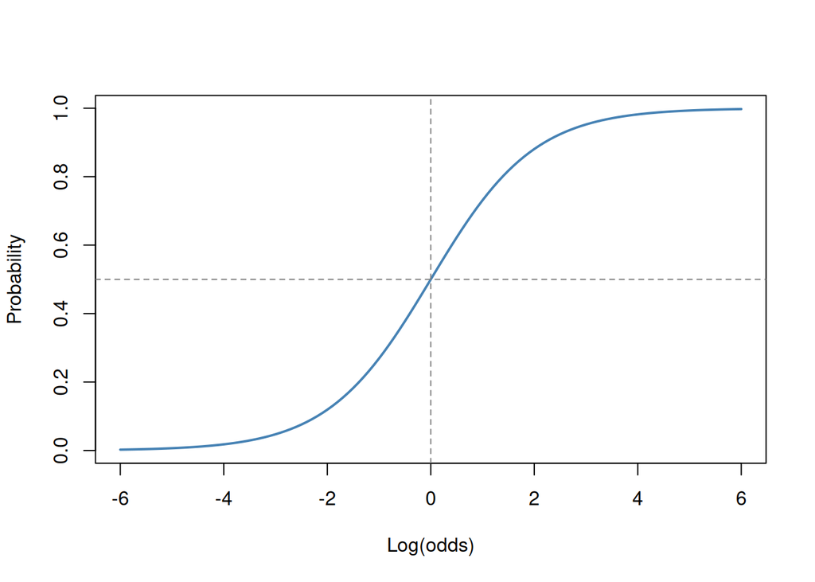

Figure 1: The logistic (S-shaped) curve converts log(odds) back into a probability

```r
log_odds <- seq(-6, 6, by = 0.1)
prob     <- exp(log_odds) / (1 + exp(log_odds))   # same as plogis(log_odds)

plot(log_odds, prob, type = "l", lwd = 2, col = "steelblue",
     xlab = "Log(odds)", ylab = "Probability")
abline(h = 0.5, v = 0, lty = 2, col = "gray50")
```

Figure 1 shows why logistic regression predictions always stay between 0 and 1. No matter how large or small the log(odds) gets, the curve flattens out before reaching 0 or 1.[^1]

# 3 Odds Ratio and Log(Odds Ratio)

## 3.1 What Does an Odds Ratio Tell Us?

> **Prompt:** What is an odds ratio, and how do you interpret it?

An **odds ratio** compares the odds of an outcome in one group to the odds in another group:

$$\text{OR} = \frac{\text{Odds}_{\text{group 1}}}{\text{Odds}_{\text{group 0}}}
\tag{4}$$

- **OR = 1:** the groups have the same odds (no effect)
- **OR > 1:** the outcome is *more* likely in group 1
- **OR < 1:** the outcome is *less* likely in group 1

The **log(OR)** follows the same idea on the log scale: 0 means no effect, positive means higher odds, and negative means lower odds.

## 3.2 Worked Example: Email Campaign

> **Prompt:** Calculate the odds, odds ratio, and log(odds ratio) for a two-group example, and show how they connect to a logistic regression.

To make this concrete, I use a marketing example. A retailer sends a promotional email to 1,000 customers and holds out 1,000 customers as a control group. Then it tracks who makes a purchase.

```r
campaign <- data.frame(
  group     = c("Control (no email)", "Received email"),
  purchased = c(100, 200),
  no_purchase = c(900, 800)
)
campaign$total       <- campaign$purchased + campaign$no_purchase
campaign$probability <- campaign$purchased / campaign$total
campaign$odds        <- campaign$purchased / campaign$no_purchase
campaign$log_odds    <- log(campaign$odds)

kable(campaign, digits = 4,
      col.names = c("Group", "Purchased", "No purchase", "Total",
                    "Probability", "Odds", "Log(odds)"))
```

Table 3: Purchases by campaign group

| Group | Purchased | No purchase | Total | Probability | Odds | Log(odds) |
| --- | --- | --- | --- | --- | --- | --- |
| Control (no email) | 100 | 900 | 1000 | 0.1 | 0.1111 | -2.1972 |
| Received email | 200 | 800 | 1000 | 0.2 | 0.2500 | -1.3863 |

**Step 1: Odds**

- Control odds $= 100 / 900 = 0.1111$
- Email odds $= 200 / 800 = 0.2500$

**Step 2: Odds Ratio**

$$\text{OR} = \frac{0.2500}{0.1111} = 2.25$$

The odds of purchasing are **2.25 times higher** for customers who received the email. Put another way, the email is associated with a **125% increase in the odds** of purchase, since $(2.25 - 1) \times 100 = 125\%$.

**Step 3: Log(OR)**

$$\log(2.25) = 0.8109$$

The log(OR) is positive, which matches the conclusion that the email raises the odds of purchase.

**Step 4: In R**

```r
odds_control <- campaign$odds[1]
odds_email   <- campaign$odds[2]

odds_ratio <- odds_email / odds_control
log_or     <- log(odds_ratio)

c(odds_ratio = odds_ratio, log_or = log_or)
```

```
odds_ratio     log_or
 2.2500000  0.8109302
```

**ImportantOdds Ratio Is Not the Same as “Twice as Likely”**

The purchase *probability* doubled, from 10% to 20%, so the **relative risk** is 2.0. The **odds ratio** is 2.25. The two numbers are close only when the outcome is rare. When I explain results to a business audience, I need to be careful to say “the *odds* are 2.25 times higher,” not “customers are 2.25 times more likely to buy.”

## 3.3 Connecting the Odds Ratio to Logistic Regression

> **Prompt:** How do the coefficients of a logistic regression relate to log(odds) and the odds ratio?

To check that the manual calculation matches the model, I rebuild the data at the customer level and fit a logistic regression with `glm()`.

```r
customers <- data.frame(
  email    = rep(c(0, 0, 1, 1), times = c(100, 900, 200, 800)),
  purchase = rep(c(1, 0, 1, 0), times = c(100, 900, 200, 800))
)

model_email <- glm(purchase ~ email, data = customers, family = binomial)
summary(model_email)$coefficients
```

```
              Estimate Std. Error    z value     Pr(>|z|)
(Intercept) -2.1972246  0.1054006 -20.846420 1.642610e-96
email        0.8109302  0.1317546   6.154853 7.514733e-10
```

```r
coefs <- coef(model_email)

compare <- data.frame(
  quantity = c("Intercept (b0)", "Slope for email (b1)", "exp(b1)"),
  model    = c(coefs[1], coefs[2], exp(coefs[2])),
  by_hand  = c(log(100/900), log_or, odds_ratio),
  meaning  = c("Log(odds) of purchase for the control group",
               "Log(OR): email vs. control",
               "Odds ratio: email vs. control")
)

kable(compare, digits = 4, row.names = FALSE,
      col.names = c("Quantity", "From glm()", "By hand", "Meaning"))
```

Table 4: The model coefficients match the hand calculations

| Quantity | From glm() | By hand | Meaning |
| --- | --- | --- | --- |
| Intercept (b0) | -2.1972 | -2.1972 | Log(odds) of purchase for the control group |
| Slope for email (b1) | 0.8109 | 0.8109 | Log(OR): email vs. control |
| exp(b1) | 2.2500 | 2.2500 | Odds ratio: email vs. control |

Table 4 shows the most important takeaway from this module:

- The **intercept** is the log(odds) of the outcome for the reference group.
- Each **slope coefficient** is a **log(odds ratio)**.
- **Exponentiating** a slope with `exp()` turns it into an **odds ratio**, which is much easier to explain.

# 4 Interpreting a Continuous Predictor

> **Prompt:** How do you interpret a logistic regression coefficient when the predictor is continuous?

With a continuous predictor, the coefficient is the change in log(odds) for a **one-unit increase** in $X$. I practiced this with the built-in `mtcars` data. The model predicts whether a car has a manual transmission (`am = 1`) from its weight (`wt`, in 1,000 lbs).

```r
model_wt <- glm(am ~ wt, data = mtcars, family = binomial)

b1    <- coef(model_wt)["wt"]
or_wt <- exp(b1)

round(c(log_or = unname(b1), odds_ratio = unname(or_wt)), 4)
```

```
    log_or odds_ratio
   -4.0240     0.0179
```

**Interpretation:**

- **Log(OR):** each additional 1,000 lbs of weight changes the log(odds) of a manual transmission by -4.024.
- **Odds ratio:** each additional 1,000 lbs multiplies the odds of a manual transmission by 0.0179, which is a decrease of about 98.2% in the odds.

Heavier cars are much less likely to be manual. The coefficient is negative, the odds ratio is below 1, and both point the same way.

```r
new_cars <- data.frame(wt = c(2.5, 3.0, 3.5))
new_cars$log_odds    <- predict(model_wt, new_cars, type = "link")
new_cars$probability <- predict(model_wt, new_cars, type = "response")

kable(new_cars, digits = 3,
      col.names = c("Weight (1,000 lbs)", "Predicted log(odds)", "Predicted probability"))
```

| Weight (1,000 lbs) | Predicted log(odds) | Predicted probability |
| --- | --- | --- |
| 2.5 | 1.980 | 0.879 |
| 3.0 | -0.032 | 0.492 |
| 3.5 | -2.044 | 0.115 |

**Tip`type = "link"` vs. `type = "response"`**

`predict()` returns **log(odds)** by default (`type = "link"`). To get a **probability**, I need `type = "response"`. Forgetting this is an easy way to report a wrong answer.

# 5 Summary of What I Need to Know

Table 5: Key formulas for logistic regression

| Concept | Formula | No-effect value | How to read it |
| --- | --- | --- | --- |
| Probability | $p$ | — | Chance out of the total |
| Odds | $p / (1-p)$ | 1 | Event vs. non-event |
| Log(odds) | $\log\big(p/(1-p)\big)$ | 0 | Scale the model predicts on |
| Odds ratio | $\text{Odds}_1 / \text{Odds}_0$ | 1 | Multiplier on the odds |
| Log(OR) | $\log(\text{OR})$ | 0 | A logistic regression slope |

**Main lessons from this module:**

1. Logistic regression is linear on the **log(odds)** scale, not the probability scale (Equation 3).
2. Slope coefficients are **log(odds ratios)**. I use `exp()` to turn them into **odds ratios** for interpretation.
3. An odds ratio describes a change in **odds**, not in probability. I should word business conclusions carefully.
4. I can use `plogis()` or `predict(..., type = "response")` to convert predictions back into probabilities.

# 6 Tool Use

I used Claude (Anthropic) to help organize this reflection and to check the R code and the worked calculations. I reviewed every step and can explain each concept and line of code on my own.

# 7 Appendix

- **Published report (GitHub Pages):** https://buenoalexa11.github.io/IBM6540-Reports/CP-W05-2-Reflections-on-Video-Quiz-Review.html
- **QMD file on GitHub:** https://github.com/Buenoalexa11/IBM6540-Reports/blob/main/CP-W05-2-Reflections-on-Video-Quiz-Review.qmd
- **GitHub repository:** https://github.com/Buenoalexa11/IBM6540-Reports

## Footnotes

[^1]: In R, `plogis()` converts log(odds) to a probability and `qlogis()` converts a probability to log(odds). They are shortcuts for the formulas written out in the code above.